# Importing required packages

```python
import pandas as pd
import numpy as np
import requests
import tweepy
import os
import seaborn as sns
import json
import matplotlib.pyplot as plt
```

### Reading dataset and printing first two rows

```python
df_twitter_archive =  pd.read_csv('twitter-archive-enhanced.csv')
df_twitter_archive.head(2)
```

|  | tweet_id | in_reply_to_status_id | in_reply_to_user_id | timestamp | source | text | retweeted_status_id | retweeted_status_user_id | retweeted_status_timestamp | expanded_urls | rating_numerator | rating_denominator | name | doggo | floofer | pupper | puppo |
| --- | --- | --- | --- | --- | --- | --- | --- | --- | --- | --- | --- | --- | --- | --- | --- | --- | --- |
| 0 | 892420643555336193 | NaN | NaN | 2017-08-01 16:23:56 +0000 | <a href="http://twitter.com/download/iphone" r... | This is Phineas. He's a mystical boy. Only eve... | NaN | NaN | NaN | https://twitter.com/dog_rates/status/892420643... | 13 | 10 | Phineas | None | None | None | None |
| 1 | 892177421306343426 | NaN | NaN | 2017-08-01 00:17:27 +0000 | <a href="http://twitter.com/download/iphone" r... | This is Tilly. She's just checking pup on you.... | NaN | NaN | NaN | https://twitter.com/dog_rates/status/892177421... | 13 | 10 | Tilly | None | None | None | None |

#### Gathering image prediction file on udacity hosted server

Using python request --

```python
url = 'https://d17h27t6h515a5.cloudfront.net/topher/2017/August/599fd2ad_image-predictions/image-predictions.tsv'
response = requests.get(url)
open('image_predictions.tsv', 'wb').write(response.content)
```

```
335079
```

```python
df_image_prediction = pd.read_csv('image_predictions.tsv',sep='\t')
df_image_prediction.head(2)
```

|  | tweet_id | jpg_url | img_num | p1 | p1_conf | p1_dog | p2 | p2_conf | p2_dog | p3 | p3_conf | p3_dog |
| --- | --- | --- | --- | --- | --- | --- | --- | --- | --- | --- | --- | --- |
| 0 | 666020888022790149 | https://pbs.twimg.com/media/CT4udn0WwAA0aMy.jpg | 1 | Welsh_springer_spaniel | 0.465074 | True | collie | 0.156665 | True | Shetland_sheepdog | 0.061428 | True |
| 1 | 666029285002620928 | https://pbs.twimg.com/media/CT42GRgUYAA5iDo.jpg | 1 | redbone | 0.506826 | True | miniature_pinscher | 0.074192 | True | Rhodesian_ridgeback | 0.072010 | True |

## Stop running from here api call ahead will take 30-40 mins .

### Gathering twitter data throught tweepy :

my application was not accepted thats why i am using file provided but still i have written the code that if in future my application for twitter api got approved i will be using this.

```python
CONSUMER_KEY = ''
CONSUMER_SECRET = ''
OAUTH_TOKEN = ''
OAUTH_TOKEN_SECRET =''


auth = tweepy.OAuthHandler(CONSUMER_KEY, CONSUMER_SECRET)
auth.set_access_token(OAUTH_TOKEN, OAUTH_TOKEN_SECRET)

api = tweepy.API(auth,
                 parser = tweepy.parsers.JSONParser(),
                 wait_on_rate_limit = True,
                 wait_on_rate_limit_notify = True)


#Download Tweepy status object based on Tweet ID and store in list
# Fetch tweets from the twitter API using the following loop:
list_of_tweets = []
# Tweets that can't be found are saved in the list below:
cant_find_tweets_for_those_ids = []
for each_id in my_ids:
    try:
        list_of_tweets.append(api.get_status(each_id))
    except Exception as e:
        cant_find_tweets_for_those_ids.append(each_id)
```

```python
# check data in list :

print("The list of tweets" ,len(list_of_tweets))
print("The list of tweets no found" , len(cant_find_tweets_for_those_ids))
```

```python
#Then in this code block we isolate the json part of each tweepy
#status object that we have downloaded and we add them all into a list

my_list_of_dicts = []
for each_json_tweet in list_of_tweets:
    my_list_of_dicts.append(each_json_tweet)
```

```python
with open('tweet_json.txt', 'w') as file:
        file.write(json.dumps(my_list_of_dicts, indent=4))
```

```python
#identify information of interest from JSON dictionaries in txt file
#and put it in a dataframe called tweet JSON
my_demo_list = []
with open('tweet_json.txt',encoding ='utf-8') as json_file:
    all_data = json.load(json_file)
    for each_dictionary in all_data:
        tweet_id = each_dictionary['id']
        whole_tweet = each_dictionary['text']
        only_url = whole_tweet[whole_tweet.find('https'):]
        favorite_count = each_dictionary['favorite_count']
        retweet_count = each_dictionary['retweet_count']
        followers_count = each_dictionary['user']['followers_count']
        friends_count = each_dictionary['user']['friends_count']
        whole_source = each_dictionary['source']
        only_device = whole_source[whole_source.find('rel="nofollow">') + 15:-4]
        source = only_device
        retweeted_status = each_dictionary['retweeted_status'] = each_dictionary.get('retweeted_status', 'Original tweet')
        if retweeted_status == 'Original tweet':
            url = only_url
        else:
            retweeted_status = 'This is a retweet'
            url = 'This is a retweet'
        my_demo_list.append({
            'tweet_id' : str(tweet_id),
            'favorite_count' : int(favorite_count),
            'retweet_count' : int(retweet_count),
            'followers_count' : int(followers_count),
            'friends_count' : int(friends_count),
            'source' : source,
            'retweeted_status' : retweeted_status,
            'url' : url,

        })
tweet_json = pd.DataFrame(my_demo_list, columns = ['tweet_id', 'favorite_count','retweet_count','followers_count', 'friends_count','source','retweeted_status', 'url'])
```

## Start Running from here now :

```python
tweet_json = pd.read_csv('tweet_json.csv')
tweet_json.head(2)
```

|  | tweet_id | favorite_count | retweet_count | followers_count | friends_count | source | retweeted_status | url |
| --- | --- | --- | --- | --- | --- | --- | --- | --- |
| 0 | 892420643555336193 | 34700 | 7246 | 8998089 | 19 | Twitter for iPhone | Original tweet | https://t.co/MgUWQ76dJU |
| 1 | 892177421306343426 | 30063 | 5428 | 8998089 | 19 | Twitter for iPhone | Original tweet | https://t.co/aQFSeaCu9L |

#### Saving dataframe tweet_json to a csv file so that you dont have to run api call again when you rerun the code :

```python
# tweet_json.to_csv('tweet_json.csv',index=False)
```

## Assesing data for issues :

#### Visual assesment / Programatic assesment

## Assessing tweet_json data

```python
tweet_json.head(2)
```

|  | tweet_id | favorite_count | retweet_count | followers_count | friends_count | source | retweeted_status | url |
| --- | --- | --- | --- | --- | --- | --- | --- | --- |
| 0 | 892420643555336193 | 34700 | 7246 | 8998089 | 19 | Twitter for iPhone | Original tweet | https://t.co/MgUWQ76dJU |
| 1 | 892177421306343426 | 30063 | 5428 | 8998089 | 19 | Twitter for iPhone | Original tweet | https://t.co/aQFSeaCu9L |

```python
tweet_json.info()
```

```
<class 'pandas.core.frame.DataFrame'>
RangeIndex: 2331 entries, 0 to 2330
Data columns (total 8 columns):
tweet_id            2331 non-null int64
favorite_count      2331 non-null int64
retweet_count       2331 non-null int64
followers_count     2331 non-null int64
friends_count       2331 non-null int64
source              2331 non-null object
retweeted_status    2331 non-null object
url                 2331 non-null object
dtypes: int64(5), object(3)
memory usage: 145.8+ KB
```

```python
tweet_json.describe()
```

|  | tweet_id | favorite_count | retweet_count | followers_count | friends_count |
| --- | --- | --- | --- | --- | --- |
| count | 2.331000e+03 | 2331.000000 | 2331.000000 | 2.331000e+03 | 2331.0 |
| mean | 7.419079e+17 | 7245.987559 | 2556.085371 | 8.998094e+06 | 19.0 |
| std | 6.823170e+16 | 11254.881617 | 4323.846386 | 4.295674e+01 | 0.0 |
| min | 6.660209e+17 | 0.000000 | 1.000000 | 8.998088e+06 | 19.0 |
| 25% | 6.782670e+17 | 1256.000000 | 518.000000 | 8.998088e+06 | 19.0 |
| 50% | 7.182469e+17 | 3139.000000 | 1189.000000 | 8.998089e+06 | 19.0 |
| 75% | 7.986692e+17 | 8856.500000 | 2965.500000 | 8.998091e+06 | 19.0 |
| max | 8.924206e+17 | 148962.000000 | 73274.000000 | 8.998485e+06 | 19.0 |

```python
tweet_json.sample(5)
```

|  | tweet_id | favorite_count | retweet_count | followers_count | friends_count | source | retweeted_status | url |
| --- | --- | --- | --- | --- | --- | --- | --- | --- |
| 725 | 780459368902959104 | 5147 | 1029 | 8998088 | 19 | Twitter for iPhone | Original tweet | https://t.co/coi4l1T2Sm |
| 1789 | 676617503762681856 | 2706 | 886 | 8998090 | 19 | Twitter for iPhone | Original tweet | https://t.co/mpQl2rJjDh |
| 182 | 855857698524602368 | 11109 | 1926 | 8998088 | 19 | Twitter for iPhone | Original tweet | https://t.co/sb73bV5Y7S |
| 1779 | 676946864479084545 | 1630 | 340 | 8998090 | 19 | Twitter for iPhone | Original tweet | https://t.co/2mXALbgBTV |
| 1035 | 741743634094141440 | 7786 | 2591 | 8998089 | 19 | Twitter for iPhone | Original tweet | https://t.co/rYxJ0UQtbE |

```python
sum(tweet_json.duplicated())
```

```
0
```

## Assesing image prediction data

```python
df_image_prediction.head(2)
```

|  | tweet_id | jpg_url | img_num | p1 | p1_conf | p1_dog | p2 | p2_conf | p2_dog | p3 | p3_conf | p3_dog |
| --- | --- | --- | --- | --- | --- | --- | --- | --- | --- | --- | --- | --- |
| 0 | 666020888022790149 | https://pbs.twimg.com/media/CT4udn0WwAA0aMy.jpg | 1 | Welsh_springer_spaniel | 0.465074 | True | collie | 0.156665 | True | Shetland_sheepdog | 0.061428 | True |
| 1 | 666029285002620928 | https://pbs.twimg.com/media/CT42GRgUYAA5iDo.jpg | 1 | redbone | 0.506826 | True | miniature_pinscher | 0.074192 | True | Rhodesian_ridgeback | 0.072010 | True |

```python
df_image_prediction.info()
```

```
<class 'pandas.core.frame.DataFrame'>
RangeIndex: 2075 entries, 0 to 2074
Data columns (total 12 columns):
tweet_id    2075 non-null int64
jpg_url     2075 non-null object
img_num     2075 non-null int64
p1          2075 non-null object
p1_conf     2075 non-null float64
p1_dog      2075 non-null bool
p2          2075 non-null object
p2_conf     2075 non-null float64
p2_dog      2075 non-null bool
p3          2075 non-null object
p3_conf     2075 non-null float64
p3_dog      2075 non-null bool
dtypes: bool(3), float64(3), int64(2), object(4)
memory usage: 152.1+ KB
```

```python
df_image_prediction.describe()
```

|  | tweet_id | img_num | p1_conf | p2_conf | p3_conf |
| --- | --- | --- | --- | --- | --- |
| count | 2.075000e+03 | 2075.000000 | 2075.000000 | 2.075000e+03 | 2.075000e+03 |
| mean | 7.384514e+17 | 1.203855 | 0.594548 | 1.345886e-01 | 6.032417e-02 |
| std | 6.785203e+16 | 0.561875 | 0.271174 | 1.006657e-01 | 5.090593e-02 |
| min | 6.660209e+17 | 1.000000 | 0.044333 | 1.011300e-08 | 1.740170e-10 |
| 25% | 6.764835e+17 | 1.000000 | 0.364412 | 5.388625e-02 | 1.622240e-02 |
| 50% | 7.119988e+17 | 1.000000 | 0.588230 | 1.181810e-01 | 4.944380e-02 |
| 75% | 7.932034e+17 | 1.000000 | 0.843855 | 1.955655e-01 | 9.180755e-02 |
| max | 8.924206e+17 | 4.000000 | 1.000000 | 4.880140e-01 | 2.734190e-01 |

```python
df_image_prediction.sample(5)
```

|  | tweet_id | jpg_url | img_num | p1 | p1_conf | p1_dog | p2 | p2_conf | p2_dog | p3 | p3_conf | p3_dog |
| --- | --- | --- | --- | --- | --- | --- | --- | --- | --- | --- | --- | --- |
| 139 | 668542336805281792 | https://pbs.twimg.com/media/CUcjtL8WUAAAJoz.jpg | 1 | American_Staffordshire_terrier | 0.267695 | True | French_bulldog | 0.254050 | True | Staffordshire_bullterrier | 0.212381 | True |
| 471 | 675135153782571009 | https://pbs.twimg.com/media/CV6P1lnWIAAUQHk.jpg | 1 | stove | 0.587507 | False | rotisserie | 0.051713 | False | microwave | 0.020725 | False |
| 469 | 675111688094527488 | https://pbs.twimg.com/media/CV56f54WsAEv4kJ.jpg | 1 | Labrador_retriever | 0.631501 | True | Brittany_spaniel | 0.101927 | True | Chesapeake_Bay_retriever | 0.062650 | True |
| 377 | 673213039743795200 | https://pbs.twimg.com/media/CVe7r7QVEAAc4Bg.jpg | 1 | schipperke | 0.888082 | True | groenendael | 0.047727 | True | kelpie | 0.041398 | True |
| 450 | 674739953134403584 | https://pbs.twimg.com/media/CV0oaHFW4AA9Coi.jpg | 1 | Dandie_Dinmont | 0.175915 | True | black-footed_ferret | 0.096534 | False | toy_poodle | 0.064145 | True |

```python
sum(df_image_prediction.jpg_url.duplicated())
```

```
66
```

```python
df_image_prediction.p1.value_counts()
```

```
golden_retriever             150
Labrador_retriever           100
Pembroke                      89
Chihuahua                     83
pug                           57
chow                          44
Samoyed                       43
toy_poodle                    39
Pomeranian                    38
malamute                      30
cocker_spaniel                30
French_bulldog                26
miniature_pinscher            23
Chesapeake_Bay_retriever      23
seat_belt                     22
Siberian_husky                20
Staffordshire_bullterrier     20
German_shepherd               20
Cardigan                      19
web_site                      19
Shetland_sheepdog             18
Maltese_dog                   18
teddy                         18
Eskimo_dog                    18
beagle                        18
Shih-Tzu                      17
Lakeland_terrier              17
Rottweiler                    17
Italian_greyhound             16
kuvasz                        16
                            ...
park_bench                     1
shield                         1
African_crocodile              1
pitcher                        1
pole                           1
suit                           1
mud_turtle                     1
hare                           1
beach_wagon                    1
rapeseed                       1
rain_barrel                    1
leaf_beetle                    1
bow                            1
carton                         1
robin                          1
school_bus                     1
fountain                       1
lawn_mower                     1
limousine                      1
rotisserie                     1
cup                            1
Madagascar_cat                 1
killer_whale                   1
pot                            1
cheeseburger                   1
lion                           1
dining_table                   1
hay                            1
king_penguin                   1
toilet_seat                    1
Name: p1, Length: 378, dtype: int64
```

```python
df_image_prediction.p1.value_counts()
```

```
golden_retriever             150
Labrador_retriever           100
Pembroke                      89
Chihuahua                     83
pug                           57
chow                          44
Samoyed                       43
toy_poodle                    39
Pomeranian                    38
malamute                      30
cocker_spaniel                30
French_bulldog                26
miniature_pinscher            23
Chesapeake_Bay_retriever      23
seat_belt                     22
Siberian_husky                20
Staffordshire_bullterrier     20
German_shepherd               20
Cardigan                      19
web_site                      19
Shetland_sheepdog             18
Maltese_dog                   18
teddy                         18
Eskimo_dog                    18
beagle                        18
Shih-Tzu                      17
Lakeland_terrier              17
Rottweiler                    17
Italian_greyhound             16
kuvasz                        16
                            ...
park_bench                     1
shield                         1
African_crocodile              1
pitcher                        1
pole                           1
suit                           1
mud_turtle                     1
hare                           1
beach_wagon                    1
rapeseed                       1
rain_barrel                    1
leaf_beetle                    1
bow                            1
carton                         1
robin                          1
school_bus                     1
fountain                       1
lawn_mower                     1
limousine                      1
rotisserie                     1
cup                            1
Madagascar_cat                 1
killer_whale                   1
pot                            1
cheeseburger                   1
lion                           1
dining_table                   1
hay                            1
king_penguin                   1
toilet_seat                    1
Name: p1, Length: 378, dtype: int64
```

```python
df_image_prediction.img_num.value_counts()
```

```
1    1780
2     198
3      66
4      31
Name: img_num, dtype: int64
```

```python
df_image_prediction.p1_conf.mean()
```

```
0.59454826361445778
```

```python
df_image_prediction.p2_conf.mean()
```

```
0.13458860950039181
```

```python
sum(df_image_prediction.tweet_id.duplicated())
```

```
0
```

```python
df_image_prediction.isnull().sum()
```

```
tweet_id    0
jpg_url     0
img_num     0
p1          0
p1_conf     0
p1_dog      0
p2          0
p2_conf     0
p2_dog      0
p3          0
p3_conf     0
p3_dog      0
dtype: int64
```

## Assesing twitter archive data

```python
df_twitter_archive.head(2)
```

|  | tweet_id | in_reply_to_status_id | in_reply_to_user_id | timestamp | source | text | retweeted_status_id | retweeted_status_user_id | retweeted_status_timestamp | expanded_urls | rating_numerator | rating_denominator | name | doggo | floofer | pupper | puppo |
| --- | --- | --- | --- | --- | --- | --- | --- | --- | --- | --- | --- | --- | --- | --- | --- | --- | --- |
| 0 | 892420643555336193 | NaN | NaN | 2017-08-01 16:23:56 +0000 | <a href="http://twitter.com/download/iphone" r... | This is Phineas. He's a mystical boy. Only eve... | NaN | NaN | NaN | https://twitter.com/dog_rates/status/892420643... | 13 | 10 | Phineas | None | None | None | None |
| 1 | 892177421306343426 | NaN | NaN | 2017-08-01 00:17:27 +0000 | <a href="http://twitter.com/download/iphone" r... | This is Tilly. She's just checking pup on you.... | NaN | NaN | NaN | https://twitter.com/dog_rates/status/892177421... | 13 | 10 | Tilly | None | None | None | None |

```python
df_twitter_archive.info()
```

```
<class 'pandas.core.frame.DataFrame'>
RangeIndex: 2356 entries, 0 to 2355
Data columns (total 17 columns):
tweet_id                      2356 non-null int64
in_reply_to_status_id         78 non-null float64
in_reply_to_user_id           78 non-null float64
timestamp                     2356 non-null object
source                        2356 non-null object
text                          2356 non-null object
retweeted_status_id           181 non-null float64
retweeted_status_user_id      181 non-null float64
retweeted_status_timestamp    181 non-null object
expanded_urls                 2297 non-null object
rating_numerator              2356 non-null int64
rating_denominator            2356 non-null int64
name                          2356 non-null object
doggo                         2356 non-null object
floofer                       2356 non-null object
pupper                        2356 non-null object
puppo                         2356 non-null object
dtypes: float64(4), int64(3), object(10)
memory usage: 313.0+ KB
```

```python
df_twitter_archive.describe()
```

|  | tweet_id | in_reply_to_status_id | in_reply_to_user_id | retweeted_status_id | retweeted_status_user_id | rating_numerator | rating_denominator |
| --- | --- | --- | --- | --- | --- | --- | --- |
| count | 2.356000e+03 | 7.800000e+01 | 7.800000e+01 | 1.810000e+02 | 1.810000e+02 | 2356.000000 | 2356.000000 |
| mean | 7.427716e+17 | 7.455079e+17 | 2.014171e+16 | 7.720400e+17 | 1.241698e+16 | 13.126486 | 10.455433 |
| std | 6.856705e+16 | 7.582492e+16 | 1.252797e+17 | 6.236928e+16 | 9.599254e+16 | 45.876648 | 6.745237 |
| min | 6.660209e+17 | 6.658147e+17 | 1.185634e+07 | 6.661041e+17 | 7.832140e+05 | 0.000000 | 0.000000 |
| 25% | 6.783989e+17 | 6.757419e+17 | 3.086374e+08 | 7.186315e+17 | 4.196984e+09 | 10.000000 | 10.000000 |
| 50% | 7.196279e+17 | 7.038708e+17 | 4.196984e+09 | 7.804657e+17 | 4.196984e+09 | 11.000000 | 10.000000 |
| 75% | 7.993373e+17 | 8.257804e+17 | 4.196984e+09 | 8.203146e+17 | 4.196984e+09 | 12.000000 | 10.000000 |
| max | 8.924206e+17 | 8.862664e+17 | 8.405479e+17 | 8.874740e+17 | 7.874618e+17 | 1776.000000 | 170.000000 |

```python
df_twitter_archive.head(3)
```

|  | tweet_id | in_reply_to_status_id | in_reply_to_user_id | timestamp | source | text | retweeted_status_id | retweeted_status_user_id | retweeted_status_timestamp | expanded_urls | rating_numerator | rating_denominator | name | doggo | floofer | pupper | puppo |
| --- | --- | --- | --- | --- | --- | --- | --- | --- | --- | --- | --- | --- | --- | --- | --- | --- | --- |
| 0 | 892420643555336193 | NaN | NaN | 2017-08-01 16:23:56 +0000 | <a href="http://twitter.com/download/iphone" r... | This is Phineas. He's a mystical boy. Only eve... | NaN | NaN | NaN | https://twitter.com/dog_rates/status/892420643... | 13 | 10 | Phineas | None | None | None | None |
| 1 | 892177421306343426 | NaN | NaN | 2017-08-01 00:17:27 +0000 | <a href="http://twitter.com/download/iphone" r... | This is Tilly. She's just checking pup on you.... | NaN | NaN | NaN | https://twitter.com/dog_rates/status/892177421... | 13 | 10 | Tilly | None | None | None | None |
| 2 | 891815181378084864 | NaN | NaN | 2017-07-31 00:18:03 +0000 | <a href="http://twitter.com/download/iphone" r... | This is Archie. He is a rare Norwegian Pouncin... | NaN | NaN | NaN | https://twitter.com/dog_rates/status/891815181... | 12 | 10 | Archie | None | None | None | None |

```python
df_twitter_archive.columns
```

```
Index(['tweet_id', 'in_reply_to_status_id', 'in_reply_to_user_id', 'timestamp',
       'source', 'text', 'retweeted_status_id', 'retweeted_status_user_id',
       'retweeted_status_timestamp', 'expanded_urls', 'rating_numerator',
       'rating_denominator', 'name', 'doggo', 'floofer', 'pupper', 'puppo'],
      dtype='object')
```

```python
df_twitter_archive.isnull().sum()
```

```
tweet_id                         0
in_reply_to_status_id         2278
in_reply_to_user_id           2278
timestamp                        0
source                           0
text                             0
retweeted_status_id           2175
retweeted_status_user_id      2175
retweeted_status_timestamp    2175
expanded_urls                   59
rating_numerator                 0
rating_denominator               0
name                             0
doggo                            0
floofer                          0
pupper                           0
puppo                            0
dtype: int64
```

```python
sum(df_twitter_archive['tweet_id'].duplicated())
```

```
0
```

```python
df_twitter_archive['source'][0]
```

```
'<a href="http://twitter.com/download/iphone" rel="nofollow">Twitter for iPhone</a>'
```

```python
df_twitter_archive['source'][0]
```

```
'<a href="http://twitter.com/download/iphone" rel="nofollow">Twitter for iPhone</a>'
```

```python
# Checking all different values of rating numerator
df_twitter_archive.rating_numerator.value_counts()
```

```
12      558
11      464
10      461
13      351
9       158
8       102
7        55
14       54
5        37
6        32
3        19
4        17
1         9
2         9
420       2
```

[output cut: 26 more lines]

##### Checking each value one by one for irregularities :

```python
# selecting some random values and inspecting them for reason of irregularitits
print(df_twitter_archive.loc[df_twitter_archive.rating_numerator == 204, 'text'])
print(df_twitter_archive.loc[df_twitter_archive.rating_numerator == 143, 'text'])
print(df_twitter_archive.loc[df_twitter_archive.rating_numerator == 666, 'text'])
print(df_twitter_archive.loc[df_twitter_archive.rating_numerator == 1176, 'text'])
print(df_twitter_archive.loc[df_twitter_archive.rating_numerator == 144, 'text'])
```

```
1120    Say hello to this unbelievably well behaved sq...
Name: text, dtype: object
1634    Two sneaky puppers were not initially seen, mo...
Name: text, dtype: object
189    @s8n You tried very hard to portray this good ...
Name: text, dtype: object
Series([], Name: text, dtype: object)
1779    IT'S PUPPERGEDDON. Total of 144/120 ...I think...
Name: text, dtype: object
```

```python
#print whole text in order to verify numerators and denominators
print(df_twitter_archive['text'][1120]) #17 dogs
print(df_twitter_archive['text'][1634]) #13 dogs
print(df_twitter_archive['text'][313]) #just a tweet to explain actual ratings, this will be ignored when cleaning data
print(df_twitter_archive['text'][189]) #no picture, this will be ignored when cleaning data
print(df_twitter_archive['text'][1779]) #12 dogs
```

```
Say hello to this unbelievably well behaved squad of doggos. 204/170 would try to pet all at once https://t.co/yGQI3He3xv
Two sneaky puppers were not initially seen, moving the rating to 143/130. Please forgive us. Thank you https://t.co/kRK51Y5ac3
@jonnysun @Lin_Manuel ok jomny I know you're excited but 960/00 isn't a valid rating, 13/10 is tho
@s8n You tried very hard to portray this good boy as not so good, but you have ultimately failed. His goodness shines through. 666/10
IT'S PUPPERGEDDON. Total of 144/120 ...I think https://t.co/ZanVtAtvIq
```

```python
# Checking all different values of rating denominator

df_twitter_archive.rating_denominator.value_counts()
```

```
10     2333
11        3
50        3
80        2
20        2
2         1
16        1
40        1
70        1
15        1
90        1
110       1
120       1
130       1
150       1
170       1
7         1
0         1
Name: rating_denominator, dtype: int64
```

```python
print(df_twitter_archive.loc[df_twitter_archive.rating_denominator == 11, 'text'])
print(df_twitter_archive.loc[df_twitter_archive.rating_denominator == 2, 'text'])
print(df_twitter_archive.loc[df_twitter_archive.rating_denominator == 16, 'text'])
print(df_twitter_archive.loc[df_twitter_archive.rating_denominator == 110, 'text'])
print(df_twitter_archive.loc[df_twitter_archive.rating_denominator == 15, 'text'])
print(df_twitter_archive.loc[df_twitter_archive.rating_denominator == 90, 'text'])
print(df_twitter_archive.loc[df_twitter_archive.rating_denominator == 130, 'text'])
print(df_twitter_archive.loc[df_twitter_archive.rating_denominator == 7, 'text'])
```

```
784     RT @dog_rates: After so many requests, this is...
1068    After so many requests, this is Bretagne. She ...
1662    This is Darrel. He just robbed a 7/11 and is i...
Name: text, dtype: object
2335    This is an Albanian 3 1/2 legged  Episcopalian...
Name: text, dtype: object
1663    I'm aware that I could've said 20/16, but here...
Name: text, dtype: object
1635    Someone help the girl is being mugged. Several...
Name: text, dtype: object
342    @docmisterio account started on 11/15/15
Name: text, dtype: object
1228    Happy Saturday here's 9 puppers on a bench. 99...
Name: text, dtype: object
1634    Two sneaky puppers were not initially seen, mo...
Name: text, dtype: object
516    Meet Sam. She smiles 24/7 &amp; secretly aspir...
Name: text, dtype: object
```

```python
df_twitter_archive.iloc[2335]
```

```
tweet_id                                                     666287406224695296
in_reply_to_status_id                                                       NaN
in_reply_to_user_id                                                         NaN
timestamp                                             2015-11-16 16:11:11 +0000
source                        <a href="http://twitter.com/download/iphone" r...
text                          This is an Albanian 3 1/2 legged  Episcopalian...
retweeted_status_id                                                         NaN
retweeted_status_user_id                                                    NaN
retweeted_status_timestamp                                                  NaN
expanded_urls                 https://twitter.com/dog_rates/status/666287406...
rating_numerator                                                              1
rating_denominator                                                            2
name                                                                         an
doggo                                                                      None
floofer                                                                    None
pupper                                                                     None
puppo                                                                      None
Name: 2335, dtype: object
```

```python
print(df_twitter_archive['text'][784]) # Retweet -- will be deleted
print(df_twitter_archive['text'][1068]) # Actual rating 14/10 manual change
print(df_twitter_archive['text'][1662]) # Actual rating 10/10 manual change
print(df_twitter_archive['text'][2335]) # Actual rating 9/10 manual change
print(df_twitter_archive['text'][1663]) # Tweet to explain rating
print(df_twitter_archive['text'][1635]) # 11 dogs
```

```
RT @dog_rates: After so many requests, this is Bretagne. She was the last surviving 9/11 search dog, and our second ever 14/10. RIP https:/…
After so many requests, this is Bretagne. She was the last surviving 9/11 search dog, and our second ever 14/10. RIP https://t.co/XAVDNDaVgQ
This is Darrel. He just robbed a 7/11 and is in a high speed police chase. Was just spotted by the helicopter 10/10 https://t.co/7EsP8LmSp5
This is an Albanian 3 1/2 legged  Episcopalian. Loves well-polished hardwood flooring. Penis on the collar. 9/10 https://t.co/d9NcXFKwLv
I'm aware that I could've said 20/16, but here at WeRateDogs we are very professional. An inconsistent rating scale is simply irresponsible
Someone help the girl is being mugged. Several are distracting her while two steal her shoes. Clever puppers 121/110 https://t.co/1zfnTJLt55
```

#### by exploring (Reviewer point )i found that the data has some wrong numerators and denominators in rating that i will change manually

```python
with pd.option_context('max_colwidth', 200):
    display(df_twitter_archive[df_twitter_archive['text'].str.contains(r"(\d+\.\d*\/\d+)")]
            [['tweet_id', 'text', 'rating_numerator', 'rating_denominator']])
```

|  | tweet_id | text | rating_numerator | rating_denominator |
| --- | --- | --- | --- | --- |
| 45 | 883482846933004288 | This is Bella. She hopes her smile made you smile. If not, she is also offering you her favorite monkey. 13.5/10 https://t.co/qjrljjt948 | 5 | 10 |
| 340 | 832215909146226688 | RT @dog_rates: This is Logan, the Chow who lived. He solemnly swears he's up to lots of good. H*ckin magical af 9.75/10 https://t.co/yBO5wu… | 75 | 10 |
| 695 | 786709082849828864 | This is Logan, the Chow who lived. He solemnly swears he's up to lots of good. H*ckin magical af 9.75/10 https://t.co/yBO5wuqaPS | 75 | 10 |
| 763 | 778027034220126208 | This is Sophie. She's a Jubilant Bush Pupper. Super h*ckin rare. Appears at random just to smile at the locals. 11.27/10 would smile back https://t.co/QFaUiIHxHq | 27 | 10 |
| 1689 | 681340665377193984 | I've been told there's a slight possibility he's checking his mirror. We'll bump to 9.5/10. Still a menace | 5 | 10 |
| 1712 | 680494726643068929 | Here we have uncovered an entire battalion of holiday puppers. Average of 11.26/10 https://t.co/eNm2S6p9BD | 26 | 10 |

#### here we can see that rating are wrong we will have to change them also manually

# Cleaning :

```
Quality :
    df_twitter_archive :
        1. Delete columns that wont be used for analysis(in_reply_to_status_id,in_reply_to_user_id,retweeted_status_id,retweeted_status_user_id,retweeted_status_timestamp,expanded_urls)
        2. Separate timestamp into day - month - year (3 columns)
        3. Delete retweets.
        4. Correct numerators and denominators
    df_image_prediction :
        1. Drop 66 jpg_url duplicated
        2. Create 1 column for image prediction and 1 column for confidence level
        3. Delete columns that won't be used for analysis

    tweet_json :
        1. Keep original tweets only

Tidiness :
    df_twitter_archive:
        1. Melt dogoo puppo to one col dog statge
        2. Change tweet_id to type int64 in order to merge with the other 2 tables
        3. All tables should be part of one dataset
```

### Making a copy of dataframes before cleaning

```python
twitter_archive_clean = df_twitter_archive.copy()
image_prediction_clean = df_image_prediction.copy()
tweet_json_clean = tweet_json.copy()
```

#### cleaning twitter_archive

df_twitter_archive :

```
    1. Delete columns that wont be used for analysis(in_reply_to_status_id,in_reply_to_user_id,retweeted_status_id,retweeted_status_user_id,retweeted_status_timestamp,expanded_urls)
    2. Separate timestamp into day - month - year (3 columns)
    3. Delete retweets.
    4. Correct numerators and denominators
```

```python
df_twitter_archive.retweeted_status_id.value_counts().count()
```

```
181
```

1. Twitter archive - Delete retweets .

Based on info, there are 181 values in retweeted_status_id and retweeted_status_user_id. Delete the retweets. Once I merge twitter_archive and image_prediction, I will only keep the ones with images.

-- Keeping only original tweets deleting all retweets

```python
twitter_archive_clean = twitter_archive_clean[pd.isnull(twitter_archive_clean['retweeted_status_user_id'])]
```

1. Twitter archive - Delete columns that won't be used for analysis

```python
#CODE: Delete columns no needed
twitter_archive_clean.drop(['source','in_reply_to_status_id','in_reply_to_user_id','retweeted_status_id','retweeted_status_user_id','retweeted_status_timestamp','expanded_urls'],1,inplace= True)
```

```python
print(list(twitter_archive_clean))
```

```
['tweet_id', 'timestamp', 'text', 'rating_numerator', 'rating_denominator', 'name', 'doggo', 'floofer', 'pupper', 'puppo']
```

Tidiness :

1. Twitter_archive - Melt (doggo, floofer, pupper and puppo columns) to one col dog statge

```python
twitter_archive_clean = pd.melt(twitter_archive_clean,id_vars = ['tweet_id','timestamp','text','rating_numerator','rating_denominator','name'],var_name = 'dogs',value_name = 'dogs_stage')
```

```python
# Drop dogs
twitter_archive_clean = twitter_archive_clean.drop('dogs', 1)

# Sort by dogs_stage then drop duplicated based on tweet_id except the last occurrence
twitter_archive_clean = twitter_archive_clean.sort_values('dogs_stage').drop_duplicates(subset='tweet_id',
                                                                                        keep='last')
```

```python
# Test :
twitter_archive_clean['dogs_stage'].value_counts()
```

```
None       1831
pupper      234
doggo        75
puppo        25
floofer      10
Name: dogs_stage, dtype: int64
```

```python
twitter_archive_clean.head()
```

|  | tweet_id | timestamp | text | rating_numerator | rating_denominator | name | dogs_stage |
| --- | --- | --- | --- | --- | --- | --- | --- |
| 2095 | 667443425659232256 | 2015-11-19 20:44:47 +0000 | Exotic dog here. Long neck. Weird paws. Obsess... | 6 | 10 | None | None |
| 2094 | 667453023279554560 | 2015-11-19 21:22:56 +0000 | Meet Cupcake. I would do unspeakable things fo... | 11 | 10 | Cupcake | None |
| 2093 | 667455448082227200 | 2015-11-19 21:32:34 +0000 | This is Reese and Twips. Reese protects Twips.... | 7 | 10 | Reese | None |
| 2092 | 667470559035432960 | 2015-11-19 22:32:36 +0000 | This is a northern Wahoo named Kohl. He runs t... | 11 | 10 | a | None |
| 2091 | 667491009379606528 | 2015-11-19 23:53:52 +0000 | Two dogs in this one. Both are rare Jujitsu Py... | 7 | 10 | None | None |

### Indices are not ordered

```python
# indices = np.arange(twitter_archive_clean.shape[0])
# twitter_archive_clean.index = indices
```

1. Twitter_archive - Separate timestamp into day - month - year (3 columns)

First convert timestamp to datetime. Then extract year, month and day to new columns. Finally drop timestamp column.

```python
# convert timestamp to datetime
twitter_archive_clean.timestamp = pd.to_datetime(twitter_archive_clean.timestamp)
```

```python
#extract year, month and day to new columns

twitter_archive_clean["day"] = twitter_archive_clean['timestamp'].map(lambda x: x.day)
twitter_archive_clean["month"] = twitter_archive_clean['timestamp'].map(lambda x: x.month)
twitter_archive_clean["year"] = twitter_archive_clean['timestamp'].map(lambda x: x.year)
```

```python
# Test :
twitter_archive_clean.sample(5)
```

|  | tweet_id | timestamp | text | rating_numerator | rating_denominator | name | dogs_stage | day | month | year |
| --- | --- | --- | --- | --- | --- | --- | --- | --- | --- | --- |
| 2490 | 828372645993398273 | 2017-02-05 22:40:03 | This is Alexander Hamilpup. He was one of the ... | 12 | 10 | Alexander | None | 5 | 2 | 2017 |
| 5635 | 694356675654983680 | 2016-02-02 03:08:26 | This pupper only appears through the hole of a... | 10 | 10 | None | pupper | 2 | 2 | 2016 |
| 3053 | 742161199639494656 | 2016-06-13 01:06:33 | This is Doug. He's trying to float away. 12/10... | 12 | 10 | Doug | None | 13 | 6 | 2016 |
| 3501 | 691793053716221953 | 2016-01-26 01:21:31 | We usually don't rate penguins but this one is... | 10 | 10 | None | None | 26 | 1 | 2016 |
| 2572 | 815639385530101762 | 2017-01-01 19:22:38 | This is Titan. His nose is quite chilly. Reque... | 12 | 10 | Titan | None | 1 | 1 | 2017 |

```python
# Drop the timestamp col not needed anymore
twitter_archive_clean.drop('timestamp',1,inplace = True)
```

```python
# Test
twitter_archive_clean.sample(5)
```

|  | tweet_id | text | rating_numerator | rating_denominator | name | dogs_stage | day | month | year |
| --- | --- | --- | --- | --- | --- | --- | --- | --- | --- |
| 3369 | 701981390485725185 | This is Fiji. She's a Powdered Stegafloof. Ver... | 12 | 10 | Fiji | None | 23 | 2 | 2016 |
| 3815 | 676590572941893632 | After some outrage from the crowd. Bubbles is ... | 7 | 10 | None | None | 15 | 12 | 2015 |
| 2386 | 845812042753855489 | We usually don't rate polar bears but this one... | 13 | 10 | None | None | 26 | 3 | 2017 |
| 5629 | 695074328191332352 | This is Lorenzo. He's educated af. Just gradua... | 11 | 10 | Lorenzo | pupper | 4 | 2 | 2016 |
| 5771 | 686007916130873345 | This pupper has a magical eye. 11/10 I can't s... | 11 | 10 | None | pupper | 10 | 1 | 2016 |

1. Twitter_archive - Correc numerators

Steps :

1. first we will correct numerator that have wrong rating (wrong data extracted)
2. then we will correct dog rating in which there are multiple dogs and that are having rating denominators greater than 10
3. then we will correct their denominators also

> first we will correct numerator that have wrong rating (wrong data extracted)

```python
# Checking for wrong data :

with pd.option_context('max_colwidth', 200):
    display(twitter_archive_clean[twitter_archive_clean['text'].str.contains(r"(\d+\.\d*\/\d+)")]
            [['tweet_id', 'text', 'rating_numerator', 'rating_denominator']])
```

|  | tweet_id | text | rating_numerator | rating_denominator |
| --- | --- | --- | --- | --- |
| 42 | 883482846933004288 | This is Bella. She hopes her smile made you smile. If not, she is also offering you her favorite monkey. 13.5/10 https://t.co/qjrljjt948 | 5 | 10 |
| 3685 | 681340665377193984 | I've been told there's a slight possibility he's checking his mirror. We'll bump to 9.5/10. Still a menace | 5 | 10 |
| 3708 | 680494726643068929 | Here we have uncovered an entire battalion of holiday puppers. Average of 11.26/10 https://t.co/eNm2S6p9BD | 26 | 10 |
| 2733 | 786709082849828864 | This is Logan, the Chow who lived. He solemnly swears he's up to lots of good. H*ckin magical af 9.75/10 https://t.co/yBO5wuqaPS | 75 | 10 |
| 4967 | 778027034220126208 | This is Sophie. She's a Jubilant Bush Pupper. Super h*ckin rare. Appears at random just to smile at the locals. 11.27/10 would smile back https://t.co/QFaUiIHxHq | 27 | 10 |

```python
# Converting datatype to float to accept float values
twitter_archive_clean[['rating_numerator', 'rating_denominator']] = twitter_archive_clean[['rating_numerator','rating_denominator']].astype(float)
```

```python
# Updating numerators manually:

twitter_archive_clean.loc[(twitter_archive_clean.tweet_id == 883482846933004288), 'rating_numerator'] = 13.5
twitter_archive_clean.loc[(twitter_archive_clean.tweet_id == 786709082849828864), 'rating_numerator'] = 9.75
twitter_archive_clean.loc[(twitter_archive_clean.tweet_id == 778027034220126208), 'rating_numerator'] = 11.27
twitter_archive_clean.loc[(twitter_archive_clean.tweet_id == 681340665377193984), 'rating_numerator'] = 9.5
twitter_archive_clean.loc[(twitter_archive_clean.tweet_id == 680494726643068929), 'rating_numerator'] = 11.26

# Testing code :
with pd.option_context('max_colwidth', 200):
    display(twitter_archive_clean[twitter_archive_clean['text'].str.contains(r"(\d+\.\d*\/\d+)")]
            [['tweet_id', 'text', 'rating_numerator', 'rating_denominator']])
```

|  | tweet_id | text | rating_numerator | rating_denominator |
| --- | --- | --- | --- | --- |
| 42 | 883482846933004288 | This is Bella. She hopes her smile made you smile. If not, she is also offering you her favorite monkey. 13.5/10 https://t.co/qjrljjt948 | 13.50 | 10.0 |
| 3685 | 681340665377193984 | I've been told there's a slight possibility he's checking his mirror. We'll bump to 9.5/10. Still a menace | 9.50 | 10.0 |
| 3708 | 680494726643068929 | Here we have uncovered an entire battalion of holiday puppers. Average of 11.26/10 https://t.co/eNm2S6p9BD | 11.26 | 10.0 |
| 2733 | 786709082849828864 | This is Logan, the Chow who lived. He solemnly swears he's up to lots of good. H*ckin magical af 9.75/10 https://t.co/yBO5wuqaPS | 9.75 | 10.0 |
| 4967 | 778027034220126208 | This is Sophie. She's a Jubilant Bush Pupper. Super h*ckin rare. Appears at random just to smile at the locals. 11.27/10 would smile back https://t.co/QFaUiIHxHq | 11.27 | 10.0 |

Twitter_archive - Correc denominators

a. manual cleaning of columns

Five tweets with denominator not equal to 10 for special circunstances. Update both numerators and denominators when necessary. Delete other five tweets because they do not have actual ratings.

```python
# Checking again before cleaning:
print(df_twitter_archive['text'][784]) # Retweet -- will be deleted
print(df_twitter_archive['text'][1068]) # Actual rating 14/10 manual change
print(df_twitter_archive['text'][1662]) # Actual rating 10/10 manual change
print(df_twitter_archive['text'][2335]) # Actual rating 9/10 manual change
print(df_twitter_archive['text'][1663]) # Tweet to explain rating
print(df_twitter_archive['text'][1635]) # 11 dogs
```

```
RT @dog_rates: After so many requests, this is Bretagne. She was the last surviving 9/11 search dog, and our second ever 14/10. RIP https:/…
After so many requests, this is Bretagne. She was the last surviving 9/11 search dog, and our second ever 14/10. RIP https://t.co/XAVDNDaVgQ
This is Darrel. He just robbed a 7/11 and is in a high speed police chase. Was just spotted by the helicopter 10/10 https://t.co/7EsP8LmSp5
This is an Albanian 3 1/2 legged  Episcopalian. Loves well-polished hardwood flooring. Penis on the collar. 9/10 https://t.co/d9NcXFKwLv
I'm aware that I could've said 20/16, but here at WeRateDogs we are very professional. An inconsistent rating scale is simply irresponsible
Someone help the girl is being mugged. Several are distracting her while two steal her shoes. Clever puppers 121/110 https://t.co/1zfnTJLt55
```

```python
# extracting its tweet id to clean better
# not verifying from cleaning dataset because its not indexed properly
print(df_twitter_archive['tweet_id'][1068])
```

```
740373189193256964
```

```python
#CODE: Update both numerators and denominators
twitter_archive_clean.loc[(twitter_archive_clean.tweet_id == 740373189193256964), 'rating_numerator'] = 14
twitter_archive_clean.loc[(twitter_archive_clean.tweet_id == 740373189193256964), 'rating_denominator'] = 10

twitter_archive_clean.loc[(twitter_archive_clean.tweet_id == 682962037429899265), 'rating_numerator'] = 10
twitter_archive_clean.loc[(twitter_archive_clean.tweet_id == 682962037429899265), 'rating_denominator'] = 10

twitter_archive_clean.loc[(twitter_archive_clean.tweet_id == 666287406224695296), 'rating_numerator'] = 9
twitter_archive_clean.loc[(twitter_archive_clean.tweet_id == 666287406224695296), 'rating_denominator'] = 10

twitter_archive_clean.loc[(twitter_archive_clean.tweet_id == 722974582966214656), 'rating_numerator'] = 13
twitter_archive_clean.loc[(twitter_archive_clean.tweet_id == 722974582966214656), 'rating_denominator'] = 10

twitter_archive_clean.loc[(twitter_archive_clean.tweet_id == 716439118184652801), 'rating_numerator'] = 13.5
twitter_archive_clean.loc[(twitter_archive_clean.tweet_id == 716439118184652801), 'rating_denominator'] = 10

#CODE: Delete five tweets with no actual ratings
twitter_archive_clean = twitter_archive_clean[twitter_archive_clean['tweet_id'] != 832088576586297345]
twitter_archive_clean = twitter_archive_clean[twitter_archive_clean['tweet_id'] != 810984652412424192]
twitter_archive_clean = twitter_archive_clean[twitter_archive_clean['tweet_id'] != 682808988178739200]
twitter_archive_clean = twitter_archive_clean[twitter_archive_clean['tweet_id'] != 835246439529840640]
twitter_archive_clean = twitter_archive_clean[twitter_archive_clean['tweet_id'] != 686035780142297088]

#TEST: Left only the group dogs for programatically clean
with pd.option_context('max_colwidth', 200):
    display(twitter_archive_clean[twitter_archive_clean['rating_denominator'] != 10][['tweet_id',
                                                                                      'text',
                                                                                      'rating_numerator',
                                                                                      'rating_denominator']])
```

|  | tweet_id | text | rating_numerator | rating_denominator |
| --- | --- | --- | --- | --- |
| 3429 | 697463031882764288 | Happy Wednesday here's a bucket of pups. 44/40 would pet all at once https://t.co/HppvrYuamZ | 44.0 | 40.0 |
| 3631 | 684222868335505415 | Someone help the girl is being mugged. Several are distracting her while two steal her shoes. Clever puppers 121/110 https://t.co/1zfnTJLt55 | 121.0 | 110.0 |
| 3630 | 684225744407494656 | Two sneaky puppers were not initially seen, moving the rating to 143/130. Please forgive us. Thank you https://t.co/kRK51Y5ac3 | 143.0 | 130.0 |
| 3250 | 710658690886586372 | Here's a brigade of puppers. All look very prepared for whatever happens next. 80/80 https://t.co/0eb7R1Om12 | 80.0 | 80.0 |
| 3225 | 713900603437621249 | Happy Saturday here's 9 puppers on a bench. 99/90 good work everybody https://t.co/mpvaVxKmc1 | 99.0 | 90.0 |
| 3270 | 709198395643068416 | From left to right:\nCletus, Jerome, Alejandro, Burp, &amp; Titson\nNone know where camera is. 45/50 would hug all at once https://t.co/sedre1ivTK | 45.0 | 50.0 |
| 3347 | 704054845121142784 | Here is a whole flock of puppers. 60/50 I'll take the lot https://t.co/9dpcw6MdWa | 60.0 | 50.0 |
| 3775 | 677716515794329600 | IT'S PUPPERGEDDON. Total of 144/120 ...I think https://t.co/ZanVtAtvIq | 144.0 | 120.0 |
| 3839 | 675853064436391936 | Here we have an entire platoon of puppers. Total score: 88/80 would pet all at once https://t.co/y93p6FLvVw | 88.0 | 80.0 |
| 2538 | 820690176645140481 | The floofs have been released I repeat the floofs have been released. 84/70 https://t.co/NIYC820tmd | 84.0 | 70.0 |
| 2908 | 758467244762497024 | Why does this never happen at my front door... 165/150 https://t.co/HmwrdfEfUE | 165.0 | 150.0 |
| 3117 | 731156023742988288 | Say hello to this unbelievably well behaved squad of doggos. 204/170 would try to pet all at once https://t.co/yGQI3He3xv | 204.0 | 170.0 |

> These tweets with denominator not equal to 10 are multiple dogs. For example, tweet_id 713900603437621000 has numerator and denominators 99/90 because there are 9 dogs in the picture https://t.co/mpvaVxKmc1.

```python
#CODE: Create a new column with rating in float type to avoid converting all int column to float
twitter_archive_clean['rating'] = 10 * twitter_archive_clean['rating_numerator'] / twitter_archive_clean['rating_denominator'].astype(float)

#TEST
twitter_archive_clean.sample(5)
```

|  | tweet_id | text | rating_numerator | rating_denominator | name | dogs_stage | day | month | year | rating |
| --- | --- | --- | --- | --- | --- | --- | --- | --- | --- | --- |
| 2315 | 860563773140209665 | Meet Lorenzo. He's an avid nifty hat wearer an... | 13.0 | 10.0 | Lorenzo | None | 5 | 5 | 2017 | 13.0 |
| 6107 | 673956914389192708 | This is one esteemed pupper. Just graduated co... | 10.0 | 10.0 | one | pupper | 7 | 12 | 2015 | 10.0 |
| 2680 | 794926597468000259 | This is Mack. He's rather h*ckin sleepy. Excep... | 12.0 | 10.0 | Mack | None | 5 | 11 | 2016 | 12.0 |
| 4112 | 670427002554466305 | This is a Deciduous Trimester mix named Spork.... | 9.0 | 10.0 | a | None | 28 | 11 | 2015 | 9.0 |
| 2850 | 767884188863397888 | This is Tito. He's on the lookout. Nobody know... | 10.0 | 10.0 | Tito | None | 23 | 8 | 2016 | 10.0 |

### Cleaning image_prediction

df_image_prediction :

```
    1. Drop 66 jpg_url duplicated
    2. Create 1 column for image prediction and 1 column for confidence level
    3. Delete columns that won't be used for analysis
```

```python
image_prediction_clean = image_prediction_clean.drop_duplicates(subset=['jpg_url'], keep='last')
```

```python
image_prediction_clean.jpg_url.duplicated().sum()
```

```
0
```

```python
image_prediction_clean.head(5)
```

|  | tweet_id | jpg_url | img_num | p1 | p1_conf | p1_dog | p2 | p2_conf | p2_dog | p3 | p3_conf | p3_dog |
| --- | --- | --- | --- | --- | --- | --- | --- | --- | --- | --- | --- | --- |
| 0 | 666020888022790149 | https://pbs.twimg.com/media/CT4udn0WwAA0aMy.jpg | 1 | Welsh_springer_spaniel | 0.465074 | True | collie | 0.156665 | True | Shetland_sheepdog | 0.061428 | True |
| 1 | 666029285002620928 | https://pbs.twimg.com/media/CT42GRgUYAA5iDo.jpg | 1 | redbone | 0.506826 | True | miniature_pinscher | 0.074192 | True | Rhodesian_ridgeback | 0.072010 | True |
| 2 | 666033412701032449 | https://pbs.twimg.com/media/CT4521TWwAEvMyu.jpg | 1 | German_shepherd | 0.596461 | True | malinois | 0.138584 | True | bloodhound | 0.116197 | True |
| 3 | 666044226329800704 | https://pbs.twimg.com/media/CT5Dr8HUEAA-lEu.jpg | 1 | Rhodesian_ridgeback | 0.408143 | True | redbone | 0.360687 | True | miniature_pinscher | 0.222752 | True |
| 4 | 666049248165822465 | https://pbs.twimg.com/media/CT5IQmsXIAAKY4A.jpg | 1 | miniature_pinscher | 0.560311 | True | Rottweiler | 0.243682 | True | Doberman | 0.154629 | True |

1. Image_prediction - Create 1 column for image prediction and 1 column for confidence level

Create a function where I keep the first true prediction along the confidence level as new columns.

```python
#CODE: the first true prediction (p1, p2 or p3) will be store in these lists
dog_type = []
confidence_list = []

#create a function with nested if to capture the dog type and confidence level
# from the first 'true' prediction
def image(image_prediction_clean):
    if image_prediction_clean['p1_dog'] == True:
        dog_type.append(image_prediction_clean['p1'])
        confidence_list.append(image_prediction_clean['p1_conf'])
    elif image_prediction_clean['p2_dog'] == True:
        dog_type.append(image_prediction_clean['p2'])
        confidence_list.append(image_prediction_clean['p2_conf'])
    elif image_prediction_clean['p3_dog'] == True:
        dog_type.append(image_prediction_clean['p3'])
        confidence_list.append(image_prediction_clean['p3_conf'])
    else:
        dog_type.append('Error')
        confidence_list.append('Error')

#series objects having index the image_prediction_clean column.
image_prediction_clean.apply(image, axis=1)

#create new columns
image_prediction_clean['dog_type'] = dog_type
image_prediction_clean['confidence_list'] = confidence_list
```

```python
#drop rows that has prediction_list 'error'
image_prediction_clean = image_prediction_clean[image_prediction_clean['dog_type'] != 'Error']

#TEST:
image_prediction_clean.info()
```

```
<class 'pandas.core.frame.DataFrame'>
Int64Index: 1691 entries, 0 to 2073
Data columns (total 14 columns):
tweet_id           1691 non-null int64
jpg_url            1691 non-null object
img_num            1691 non-null int64
p1                 1691 non-null object
p1_conf            1691 non-null float64
p1_dog             1691 non-null bool
p2                 1691 non-null object
p2_conf            1691 non-null float64
p2_dog             1691 non-null bool
p3                 1691 non-null object
p3_conf            1691 non-null float64
p3_dog             1691 non-null bool
dog_type           1691 non-null object
confidence_list    1691 non-null object
dtypes: bool(3), float64(3), int64(2), object(6)
memory usage: 163.5+ KB
```

```python
#  Delete columns that won't be used for analysis

#CODE: print list of image_prediction columns
print(list(image_prediction_clean))

#Delete columns
image_prediction_clean = image_prediction_clean.drop(['img_num', 'p1',
                                                      'p1_conf', 'p1_dog',
                                                      'p2', 'p2_conf',
                                                      'p2_dog', 'p3',
                                                      'p3_conf',
                                                      'p3_dog'], 1)

#TEST
list(image_prediction_clean)
```

```
['tweet_id', 'jpg_url', 'img_num', 'p1', 'p1_conf', 'p1_dog', 'p2', 'p2_conf', 'p2_dog', 'p3', 'p3_conf', 'p3_dog', 'dog_type', 'confidence_list']
```

```
['tweet_id', 'jpg_url', 'dog_type', 'confidence_list']
```

```python
# Tweet_json - keep 2174 original tweets

#CODE:
tweet_json_clean = tweet_json_clean[tweet_json_clean['retweeted_status'] == 'Original tweet']

#TEST
tweet_json_clean['retweeted_status'].value_counts()
```

```
Original tweet    2168
Name: retweeted_status, dtype: int64
```

```python
# Tidiness - Change tweet_id to type int64 in order to merge with the other 2 tables



#CODE: change tweet_id from str to int
tweet_json_clean['tweet_id'] = tweet_json_clean['tweet_id'].astype(int)

#TEST
tweet_json_clean['tweet_id'].dtypes
```

```
dtype('int64')
```

```python
# Tidiness - All tables should be part of one dataset

#CODE: create a new dataframe that merge twitter_archive_clean and
#image_prediction_clean
df_twitter1 = pd.merge(twitter_archive_clean,
                      image_prediction_clean,
                      how = 'left', on = ['tweet_id'])

#keep rows that have picture (jpg_url)
df_twitter1 = df_twitter1[df_twitter1['jpg_url'].notnull()]

#TEST
df_twitter1.info()
```

```
<class 'pandas.core.frame.DataFrame'>
Int64Index: 1625 entries, 1 to 2169
Data columns (total 13 columns):
tweet_id              1625 non-null int64
text                  1625 non-null object
rating_numerator      1625 non-null float64
rating_denominator    1625 non-null float64
name                  1625 non-null object
dogs_stage            1625 non-null object
day                   1625 non-null int64
month                 1625 non-null int64
year                  1625 non-null int64
rating                1625 non-null float64
jpg_url               1625 non-null object
dog_type              1625 non-null object
confidence_list       1625 non-null object
dtypes: float64(3), int64(4), object(6)
memory usage: 177.7+ KB
```

```python
df_twitter = pd.merge(df_twitter1, tweet_json_clean,
                      how = 'left', on = ['tweet_id'])

#TEST
df_twitter.info()
```

```
<class 'pandas.core.frame.DataFrame'>
Int64Index: 1625 entries, 0 to 1624
Data columns (total 20 columns):
tweet_id              1625 non-null int64
text                  1625 non-null object
rating_numerator      1625 non-null float64
rating_denominator    1625 non-null float64
name                  1625 non-null object
dogs_stage            1625 non-null object
day                   1625 non-null int64
month                 1625 non-null int64
year                  1625 non-null int64
rating                1625 non-null float64
jpg_url               1625 non-null object
dog_type              1625 non-null object
confidence_list       1625 non-null object
favorite_count        1619 non-null float64
retweet_count         1619 non-null float64
followers_count       1619 non-null float64
friends_count         1619 non-null float64
source                1619 non-null object
retweeted_status      1619 non-null object
url                   1619 non-null object
dtypes: float64(7), int64(4), object(9)
memory usage: 266.6+ KB
```

```python
df_twitter['rating_numerator'].value_counts()
```

```
12.00     404
10.00     354
11.00     342
13.00     212
9.00      133
8.00       68
7.00       31
14.00      22
6.00       16
5.00       13
4.00        6
3.00        5
2.00        2
13.50       2
44.00       1
143.00      1
99.00       1
45.00       1
60.00       1
144.00      1
88.00       1
84.00       1
9.75        1
0.00        1
11.26       1
165.00      1
11.27       1
121.00      1
80.00       1
Name: rating_numerator, dtype: int64
```

## Store the clean DataFrame in a CSV file

```python
df_twitter.to_csv('twitter_archive_master.csv',
                 index=False, encoding = 'utf-8')
```

```python
df_twitter = pd.read_csv('twitter_archive_master.csv')
```

## Insights and visualisation

```python
df_twitter['dog_type'].value_counts()
```

```
golden_retriever                  142
Labrador_retriever                103
Pembroke                           94
Chihuahua                          87
pug                                60
toy_poodle                         50
chow                               45
Pomeranian                         42
Samoyed                            38
malamute                           32
Chesapeake_Bay_retriever           31
French_bulldog                     30
cocker_spaniel                     26
miniature_pinscher                 24
Eskimo_dog                         22
German_shepherd                    21
Staffordshire_bullterrier          20
Shih-Tzu                           20
Siberian_husky                     20
Maltese_dog                        19
Rottweiler                         19
Shetland_sheepdog                  19
beagle                             19
Cardigan                           19
kuvasz                             18
Lakeland_terrier                   17
basset                             17
Italian_greyhound                  17
West_Highland_white_terrier        16
American_Staffordshire_terrier     16
                                 ...
Weimaraner                          4
Scottish_deerhound                  4
Saluki                              4
Welsh_springer_spaniel              4
briard                              3
Brabancon_griffon                   3
Greater_Swiss_Mountain_dog          3
Leonberg                            3
Irish_water_spaniel                 3
komondor                            3
Irish_setter                        3
curly-coated_retriever              3
Tibetan_mastiff                     3
cairn                               3
toy_terrier                         3
black-and-tan_coonhound             2
groenendael                         2
wire-haired_fox_terrier             2
Afghan_hound                        2
Australian_terrier                  2
Sussex_spaniel                      2
Appenzeller                         2
EntleBucher                         1
standard_schnauzer                  1
silky_terrier                       1
Scotch_terrier                      1
Bouvier_des_Flandres                1
Japanese_spaniel                    1
clumber                             1
Irish_wolfhound                     1
Name: dog_type, Length: 113, dtype: int64
```

```python
df_dog_type = df_twitter.groupby('dog_type').filter(lambda x:len(x)>=25)
```

```python
order = df_dog_type['dog_type'].value_counts().index
color = sns.color_palette()[0]
```

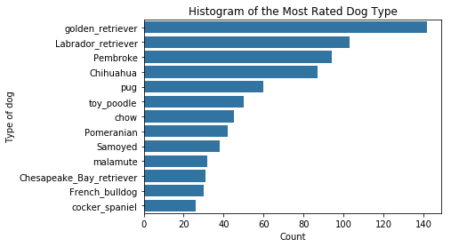

```python
sns.countplot(data=df_dog_type,y='dog_type',order = order,color = color)
plt.xlabel("Count")
plt.ylabel('Type of dog')
plt.title('Histogram of the Most Rated Dog Type');
```

```python
df = df_twitter.groupby('dog_type').mean()
df.head()
```

| dog_type | tweet_id | rating_numerator | rating_denominator | day | month | year | rating | confidence_list | favorite_count | retweet_count | followers_count | friends_count |
| --- | --- | --- | --- | --- | --- | --- | --- | --- | --- | --- | --- | --- |
| Afghan_hound | 8.095999e+17 | 8.000000 | 10.0 | 16.000000 | 6.00 | 2016.500000 | 8.000000 | 0.513621 | 10678.000000 | 2970.000000 | 8.998088e+06 | 19.0 |
| Airedale | 7.184489e+17 | 9.833333 | 10.0 | 15.916667 | 8.75 | 2015.583333 | 9.833333 | 0.583771 | 4618.916667 | 1157.750000 | 8.998090e+06 | 19.0 |
| American_Staffordshire_terrier | 7.597284e+17 | 10.312500 | 10.0 | 15.000000 | 5.25 | 2016.187500 | 10.312500 | 0.527359 | 7392.800000 | 1711.933333 | 8.998089e+06 | 19.0 |
| Appenzeller | 7.939334e+17 | 11.000000 | 10.0 | 18.500000 | 4.50 | 2016.500000 | 11.000000 | 0.503665 | 6440.500000 | 1187.000000 | 8.998089e+06 | 19.0 |
| Australian_terrier | 7.785921e+17 | 11.500000 | 10.0 | 7.000000 | 3.50 | 2016.500000 | 11.500000 | 0.307584 | 9787.000000 | 2583.500000 | 8.998088e+06 | 19.0 |

### Highest rated dog type : Bouvier_des_Flandres

### Lowest rated dog type : Japanese_spaniel

```python
df = df_twitter.groupby(['dog_type'])['rating'].mean()
df = df.sort_values(ascending=False)
df = df[:10]
```

```python
df.head()
```

```
dog_type
Bouvier_des_Flandres    13.000000
Saluki                  12.500000
briard                  12.333333
Irish_setter            12.333333
Border_terrier          12.142857
Name: rating, dtype: float64
```

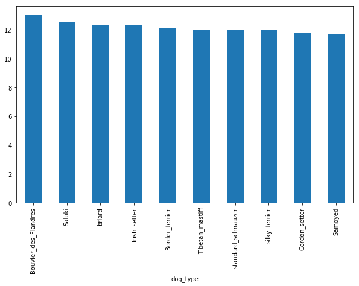

```python
df.plot(kind='bar',color=color,figsize=(10,6))
```

```python
df = df_twitter.groupby(['dog_type'])['rating'].mean()
df = df.sort_values(ascending=False)
df = df[-10:]
```

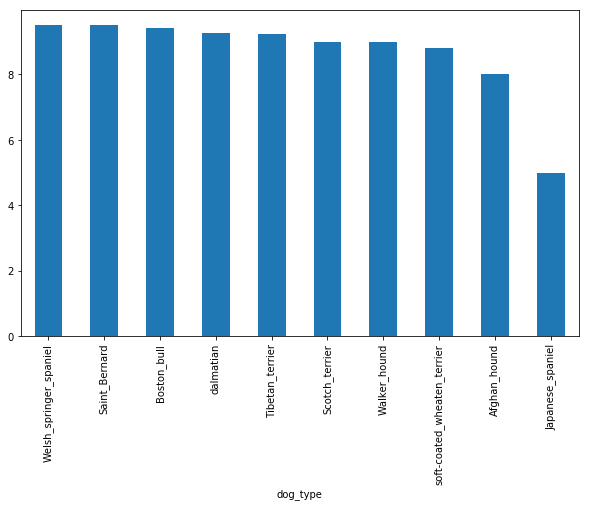

```python
df.plot(kind='bar',color=color,figsize=(10,6))
```

### Most common dog names :

```python
df_twitter.name.value_counts()
```

```
None           404
a               46
Cooper          10
Charlie         10
Lucy            10
Oliver           9
Tucker           8
Winston          7
the              7
Daisy            7
Sadie            7
Penny            7
Toby             6
Jax              6
Koda             6
Stanley          5
Oscar            5
Leo              5
Lola             5
Bella            5
Scooter          4
Rusty            4
Bentley          4
Duke             4
Cassie           4
Oakley           4
Winnie           4
Bailey           4
Gus              4
Jack             4
              ...
Danny            1
Gustav           1
Christoper       1
Burt             1
Goose            1
Craig            1
Asher            1
Huxley           1
Shadoe           1
Superpup         1
Willie           1
Zeek             1
actually         1
Tilly            1
Simba            1
Perry            1
Pubert           1
Darby            1
Godzilla         1
Grizzwald        1
Kevin            1
William          1
Colby            1
infuriating      1
Pippin           1
Brady            1
Carly            1
Jareld           1
Tuco             1
Jackie           1
Name: name, Length: 828, dtype: int64
```

```python
# Dropping irrelavent names.
df_twitter.drop(df_twitter[df_twitter['name'] == 'a'].index,inplace=True)
```

```python
df_twitter.name.value_counts()
```

```
None           404
Cooper          10
Charlie         10
Lucy            10
Oliver           9
Tucker           8
Penny            7
Daisy            7
the              7
Sadie            7
Winston          7
Koda             6
Toby             6
Jax              6
Bella            5
Oscar            5
Leo              5
Stanley          5
Lola             5
Chester          4
George           4
Sophie           4
Scooter          4
Duke             4
Dexter           4
Bear             4
Jack             4
Bentley          4
Winnie           4
Maggie           4
              ...
Zooey            1
Danny            1
Gustav           1
Christoper       1
Burt             1
Goose            1
Craig            1
Shadoe           1
Superpup         1
Kevin            1
Godzilla         1
Aja              1
Zeek             1
actually         1
Tilly            1
Simba            1
Perry            1
Pubert           1
Darby            1
Willie           1
Tuco             1
Grizzwald        1
William          1
Colby            1
infuriating      1
Pippin           1
Brady            1
Carly            1
Jareld           1
Jackie           1
Name: name, Length: 827, dtype: int64
```

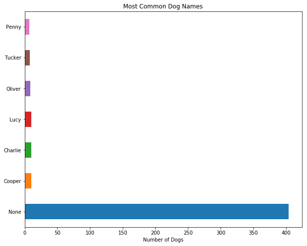

```python
df_twitter.name.value_counts()[0:7].plot('barh', figsize=(10,8), title='Most Common Dog Names').set_xlabel("Number of Dogs");
```